# Preliminary Explorations

Shaina Trevino

February 13, 2019

## Tidying Data

First steps: * import data for all years * join files * join data frames accross years * join data frames accross types * write to csv and place in project for reproducability * write code to import data * recode categorical variables with nhanes codebook

```r
demo <- import(here("data", "demo.csv"),
               setclass = "tbl_df")

su <- import(here("data", "su.csv"),
             setclass = "tbl_df")

pu <- import(here("data", "pu.csv"),
             setclass = "tbl_df")
```

```r
# changing codes to years
t_demo <- demo %>%
  janitor::clean_names() %>%
  mutate(year = case_when(sddsrvyr == 2 ~ 2001,
                          sddsrvyr == 3 ~ 2003,
                          sddsrvyr == 4 ~ 2005,
                          sddsrvyr == 5 ~ 2007,
                          sddsrvyr == 6 ~ 2009,
                          sddsrvyr == 7 ~ 2011,
                          sddsrvyr == 8 ~ 2013,
                          sddsrvyr == 9 ~ 2015,
                          TRUE ~ NA_real_))

# creating labels for categorical variables
t_demo <- t_demo %>%
  mutate(ethnicity = case_when(ridreth3 == 1 ~ "Hispanic", # combined to be more succinct
                               ridreth3 == 2 ~ "Hispanic",
                               ridreth3 == 3 ~ "White",
                               ridreth3 == 4 ~ "Black",
                               ridreth3 == 6 ~ "Asian",
                               ridreth3 == 7 ~ "Other/Multiracial",
                               TRUE ~ NA_character_))

t_demo <- t_demo %>%
  mutate(income = case_when(indhhin2 == 1 ~ "$0 - $4,999",
                            indhhin2 == 2 ~ "$5,000 to $9,999",
                            indhhin2 == 3 ~ "10,000 to $14,999",
                            indhhin2 == 4 ~ "$15,000 to $19,999",
                            indhhin2 == 5 ~ "$20,000 to $24,999",
                            indhhin2 == 6 ~ "$25,000 to $34,999",
                            indhhin2 == 7 ~ "$35,000 to $44,999",
                            indhhin2 == 8 ~ "$45,000 to $54,999",
                            indhhin2 == 9 ~ "$55,000 to $64,999",
                            indhhin2 == 10 ~ "$65,000 to $74,999",
                            indhhin2 == 11 ~ "$75,000 and Over",
                            indhhin2 == 12 ~ "Over $20,000",
                            indhhin2 == 13 ~ "Under $20,000",
                            indhhin2 == 14 ~ "$75,000 to $99,999",
                            indhhin2 == 15 ~ "$100,000 and over",
                            indhhin2 == 77 ~ "Refused",
                            indhhin2 == 99 ~ "Don't know",
                            TRUE ~ NA_character_))

t_demo <- t_demo %>%
  mutate(education = case_when(dmdeduc2 == 1 ~ "No diploma/GED",
                               dmdeduc2 == 2 ~ "No diploma/GED",
                               dmdeduc2 == 3 ~ "High school graduate/GED",
                               dmdeduc2 == 4 ~ "Some college",
                               dmdeduc2 == 5 ~ "College graduate or above",
                               TRUE ~ NA_character_))

# Coding SU variables
su <- su %>%
  janitor::clean_names() %>%
  mutate(marijuana = case_when(duq200 == 1 ~ "Yes",
                               duq200 == 2 ~ "No",
                               TRUE ~ NA_character_)) %>%
  mutate(cocaine = case_when(duq250 == 1 ~ "Yes",
                             duq250 == 2 ~ "No",
                             TRUE ~ NA_character_)) %>%
  mutate(heroin = case_when(duq290 == 1 ~ "Yes",
                            duq290 == 2 ~ "No",
                            TRUE ~ NA_character_)) %>%
  mutate(meth = case_when(duq330 == 1 ~ "Yes",
                          duq330 == 2 ~ "No",
                          TRUE ~ NA_character_))

# Coding sex variable
t_demo <- t_demo %>%
   mutate(sex = case_when(riagendr == 1 ~ "Male",
                         riagendr == 2 ~ "Female",
                         TRUE ~ NA_character_))
# joining demo with su
d <- left_join(su, t_demo, by = "seqn")
```

### Initial Plot 1

General Audience Goal: Show the trend in substance use from 2005 to 2015 by different substances and explore gender and racial differences Variables: Substance use is the count of the number of people who reported use in that year

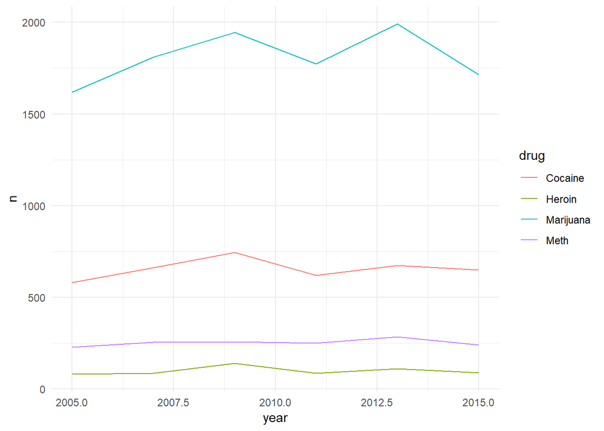

```r
h_count <- d %>%
  group_by(year) %>%
  count(heroin) %>%
  filter(heroin == "Yes")

c_count <- d %>%
  group_by(year) %>%
  count(cocaine) %>%
  filter(cocaine == "Yes")

me_count <- d %>%
  group_by(year) %>%
  count(meth) %>%
  filter(meth == "Yes")

ma_count <- d %>%
  group_by(year) %>%
  count(marijuana) %>%
  filter(marijuana == "Yes")

cj <- right_join(h_count, c_count, by = "year")
cj1 <- right_join(cj, me_count, by = "year")
su_count1 <- right_join(cj1, ma_count, by = "year")

su_count <- su_count1 %>%
  ungroup() %>%
  rename(Heroin = n.x,
         Cocaine = n.y,
         Meth = n.x.x,
         Marijuana = n.y.y) %>%
  select(year, Heroin, Cocaine, Meth, Marijuana) %>%
  gather(drug, n, Heroin:Marijuana)

ggplot(su_count, aes(year, n)) +
  geom_line(aes(color = drug))
```

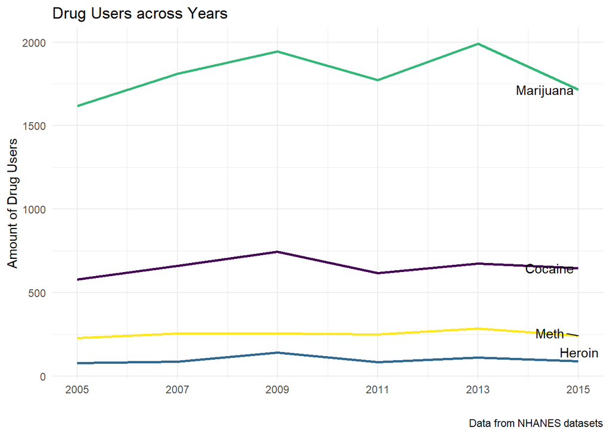

```r
ggplot(su_count, aes(year, n)) +
  geom_line(aes(color = drug), size = 1) +
  scale_x_continuous(breaks = c(2005, 2007,
                                2009, 2011,
                                2013, 2015),
                     labels = c("2005", "2007",
                                "2009", "2011",
                                "2013", "2015")) +
  scale_color_viridis_d() +
  ggrepel::geom_text_repel(data = filter(su_count, year == 2015),
                                         aes(label = drug)) +
  labs(x = " ",
       y = "Amount of Drug Users",
       title = "Drug Users across Years",
       caption = "Data from NHANES datasets") +
  guides(color = "none")
```

Changes to make for revision: * filter out marijuana to visualize illicit drugs per proposal * fct_reorder drug levels so that colors match order presented * annotate labels instead of legend - Since lines are so far apart, place label at end of trend line and delete the legend (will have to expand y limits) * Change count to percent * increased cognitive load - small increases and harder to understand proportion * edit x axis to show years more clearly * make lines thicker, change color pallete * Place points for the years in there is data for * try facet by sex or ethnicity * stack vertically on top of each other (wont work with annotated labels) * change aspect ratio * modify theme elements and place labels to reduce cognitive load * only major gridlines with data shown * Bigger facet titles * Adding labels * get rid of x axis since it is clear it is year * add space between y label and axis * center title * lighten axis text and caption * Identify dips and rises in trends and search for reasons why (policy, etc) * Nov 2012 recreational marijuana legalized * Obama ends war on drugs in 2009 * Find best aspect ratio * tidy data differently * get one dataset without joining * filter for data, gather, group_by, and count * FIGURE OUT HOW TO PLACE ANNOTATES AT DIFFERENT POINTS ON FACETS AND GET WHITE BACKGROUND BEHIND ANNOTATE TEXT.

### Revised Plot 1

```r
rpd <- d %>%
  filter(heroin == "Yes" |
         cocaine == "Yes" |
         meth == "Yes" |
         marijuana == "Yes") %>%
  select(heroin, cocaine, meth, marijuana, year, sex, ethnicity) %>%
  rename(Heroin = heroin,
         Cocaine = cocaine,
         Meth = meth,
         Marijuana = marijuana) %>%
  gather(drug, response, Heroin:Marijuana) %>%
  filter(response == "Yes") %>%
  group_by(year, drug, sex) %>%
  count() %>%
  filter(drug != "Marijuana") %>%
  ungroup() %>%
  mutate(prop = (n/sum(n)))
```

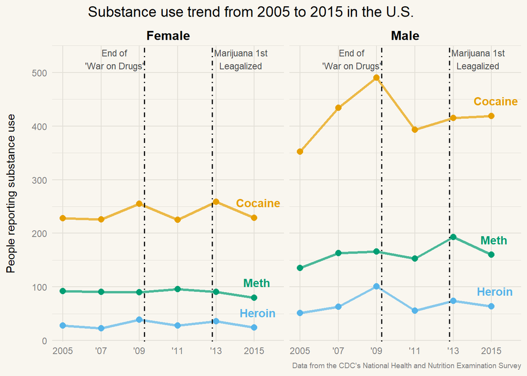

```r
ggplot(rpd, aes(year, n, color = drug)) +
  geom_line(size = 1.1, alpha = .7) +
  geom_point(size = 2.5) +
  facet_wrap(~ sex) +
  geom_text(data = filter(rpd, year == 2015),
            aes(y = n, label = drug),
            hjust = .4,
            vjust = -1.25,
            fontface = "bold") +
  geom_vline(xintercept = 2009.25, color = "black", linetype = "dotdash", size = .6) +
  geom_vline(xintercept = 2012.8, color = "black", linetype = "dotdash", size = .6) +
  annotate("text", label = "End of\n'War on Drugs'", x = 2007.7, y = 525, color = "gray30", size = 3) +
  annotate("text", label = "Marijuana 1st\nLeagalized", x = 2014.3, y = 525, color = "gray30", size = 3) + #nudging annotations for clarity
  scale_x_continuous(limits = c(2005, 2016),
                     breaks = c(2005, 2007, 2009, 2011, 2013, 2015),
                     labels = c(2005, "'07", "'09", "'11", "'13", 2015)) +
  theme(legend.position = "none",
        panel.grid.minor.x = element_blank(),
        panel.grid.major = element_line(color = "#e2dfd7"),
        panel.grid.minor = element_line(color = "#e2dfd7"),
        axis.title.x = element_blank(),
        panel.background = element_rect(fill = "#f9f6ef", color = "#f9f6ef"),
        plot.background = element_rect(fill = "#f9f6ef", color = "#f9f6ef"),
        strip.text = element_text(color = "black", face = "bold", size = 12),
        plot.title = element_text(size = 14, hjust = .25),
        plot.caption = element_text(color = "gray50", size = 7),
        axis.text = element_text(color = "gray50")) +
  labs(y = "People reporting substance use\n",
       title = "Substance use trend from 2005 to 2015 in the U.S.",
       caption = "Data from the CDC's National Health and Nutrition Examination Survey") +
  scale_color_OkabeIto()
```

From Peer Review: (1) What is the scale people are reporting substance abuse in? Thousands? Or is this really the scale of reports (I just assume the numbers are larger than that in the US)? I would either add the scale to the y-axis or a caption explaining more about the data source and the low amount. Overall, I really like this graph! I think your choice to facet by gender goes well with the trend in the data to show the spike in cocaine use (and increase in other drugs) in men as compared to women. I like your color use and your note on social trends that might be corresponding with the changing trends. Very well done!

### Initial Plot 2

Scientific Audience Goal: Show the change in distribution of how many days a person used different addictive benzodiazepines from year 2001 to 2015 Variables: days of use is continuous and types of benzodiazepines and year is categorical

```r
pud1 <- pu %>%
  janitor::clean_names() %>%
  filter(rxddrug == "LORAZEPAM" |
         rxddrug == "ALPRAZOLAM" |
         rxddrug == "DIAZEPAM" |
         rxddrug == "CLONAZEPAM") %>%
  select(seqn, rxddrug, rxddays, rxdcount) %>%
  rename(drug = rxddrug,
         days = rxddays,
         count = rxdcount)

to_join <- t_demo %>%
  rename(age = ridageyr) %>%
  select(seqn, year, age, sex)

pud <- left_join(pud1, to_join, by = "seqn") %>%
  naniar::replace_with_na(replace = list(days = 99999)) %>%
  mutate(year = factor(year))
```

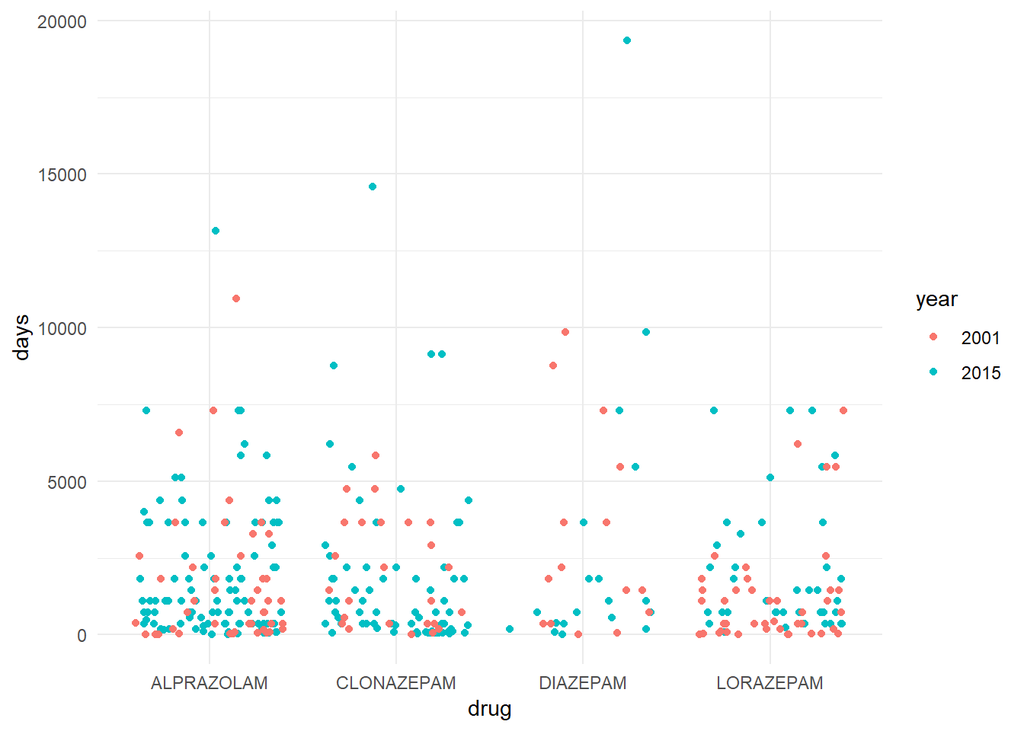

```r
ggplot(pud, aes(drug, days)) +
  geom_jitter(aes(color = year))
```

To refine: * change to ridgeline density to clearly see them since so much overlap * add variability with jitter * added jittered points * change drug names to generic names for non-medical scientists * change case of drug categories * change days to years * limit x axis to 0 on ggridges (never less than 0 years) * change scale of ridges to to get less overlap and see jittered points better * professional color pallete * get rid of legend if adding color * limit data to those under 80 * extend aspect ratio - wider for the years * add facet boxes * fct reorder density plots

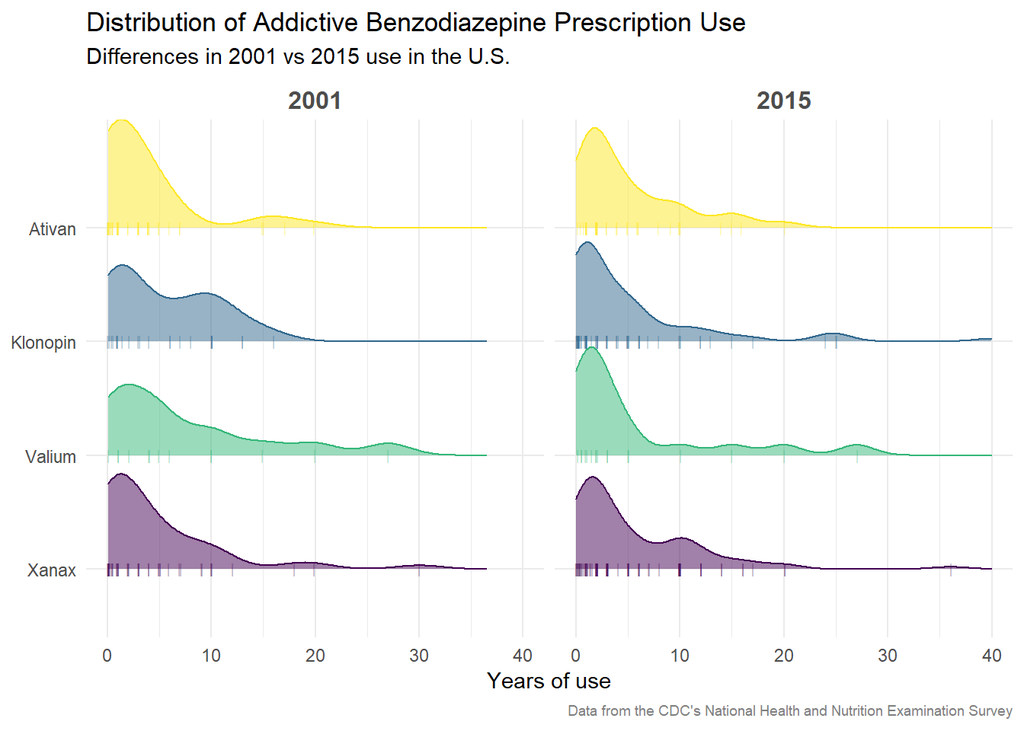

```r
rpud <- pud %>%
  mutate(use_yr = days/365) %>%
  filter(age != 80)
#JP rpud$year <- fct_relevel(rpud$year, "2015", "2001") - have 2001 before 2015

ggplot(rpud, aes(use_yr, fct_reorder(drug, use_yr), fill = drug)) +
  geom_density_ridges(aes(color = drug),
                      scale = .95,
                      alpha = .5,
                      jittered_points = TRUE,
                      position = position_points_jitter(width = .1,
                                                        height = 0),
                      point_shape = '|',
                      point_size = 2,
                      point_alpha = .4) +
  facet_wrap(~ year) +
  scale_y_discrete(breaks = c("LORAZEPAM", "CLONAZEPAM", "DIAZEPAM", "ALPRAZOLAM"),
                   labels = c("Ativan", "Klonopin", "Valium", "Xanax")) + # or delete and change case str_to_title and use specific name?
  scale_x_continuous(limits = c(0,40)) +
  theme(legend.position = "none",
        axis.title.y = element_blank(),
        strip.text = element_text(color = "gray30", face = "bold", size = 12),
        plot.caption = element_text(color = "gray50", size = 7)) +
  labs(x = "Years of use",
       title = "Distribution of Addictive Benzodiazepine Prescription Use",
       subtitle = "Differences in 2001 vs 2015 use in the U.S.",
       caption = "Data from the CDC's National Health and Nutrition Examination Survey") +
  scale_fill_viridis_d() +
  scale_color_viridis_d()
```

2ND Revision: * change color to white to not get rideline where there is no data (0 on x) * change facet to drug to see differences in years more clearly * facet by drug type and put year on y axis, so it is easier to see differences between the years over the drug types * figure out how to change point color to black to see actual distribution of points

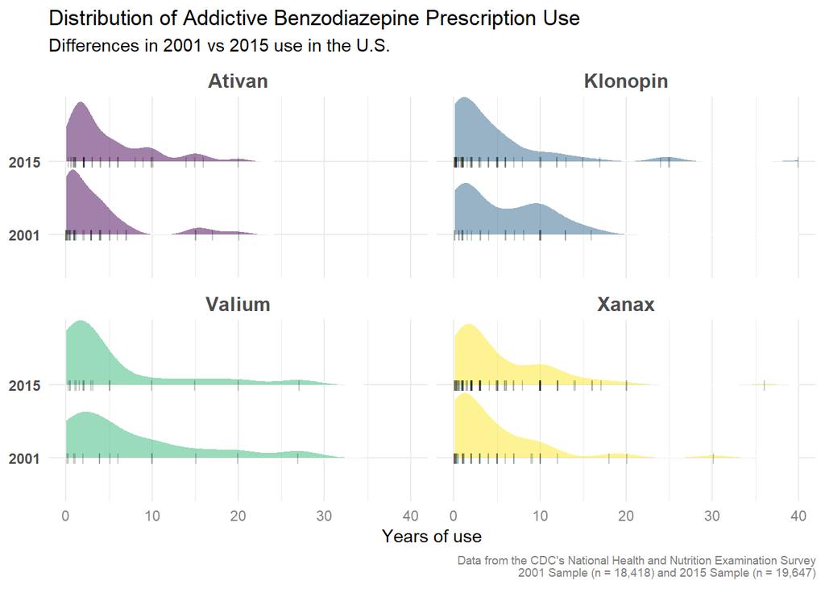

```r
rpud <- pud %>%
  mutate(use_yr = days/365,
         drug = case_when(drug == "LORAZEPAM" ~ "Ativan",
                          drug == "CLONAZEPAM" ~ "Klonopin",
                          drug == "DIAZEPAM" ~ "Valium",
                          drug == "ALPRAZOLAM" ~ "Xanax",
                          TRUE ~ NA_character_)) %>%
  filter(age != 80)

ggplot(rpud, aes(use_yr, year, fill = drug)) +
  geom_density_ridges(color = "white",
                      scale = .9,
                      alpha = .5,
                      jittered_points = TRUE,
                      position = position_points_jitter(width = .1,
                                                        height = 0),
                      point_shape = '|',
                      point_size = 2,
                      point_alpha = .35,
                      point_color = "black") +
  facet_wrap(~ drug) +
  scale_x_continuous(limits = c(0,40)) +
  theme(legend.position = "none",
        axis.title.y = element_blank(),
        axis.text.y = element_text(face = "bold"),
        axis.text.x = element_text(color = "gray50"),
        strip.text = element_text(color = "gray30", face = "bold", size = 12),
        plot.caption = element_text(color = "gray50", size = 7)) +
  labs(x = "Years of use",
       title = "Distribution of Addictive Benzodiazepine Prescription Use",
       subtitle = "Differences in 2001 vs 2015 use in the U.S.",
       caption = "Data from the CDC's National Health and Nutrition Examination Survey\n2001 Sample (n = 18,418) and 2015 Sample (n = 19,647)") +
  scale_fill_viridis_d() +
  scale_color_viridis_d()
```

```r
#aspect ratio preview not working
```

Suggestion from Peer Review: (1) These plots are beautiful! Upon first looking at the plot, I was a little confused by your use of both years to facet the difference and years of use as your variable of interest. I think I was expecting the plot to show me changes in the amount people used per day, month, year, etc due to your subtitle stating “Differences in 2001 vs 2015 use in the U.S.” It would be helpful if you could make it clear that this is years of use.

I really like your use of lines at the bottom of each density plot to also show the density of responses for each drug at that time-point, it does a good job of showing what drugs are used more than others. I also like the colors and your choice to put each of the year facets for each drug right next to each other, makes it easier for comparision.

### Initial Plot 3

Audience: Scientific community Goal: Show how age of first substance use differs by income for each substance type Variables: age of first substance use is categorical, income and substance types are categorical

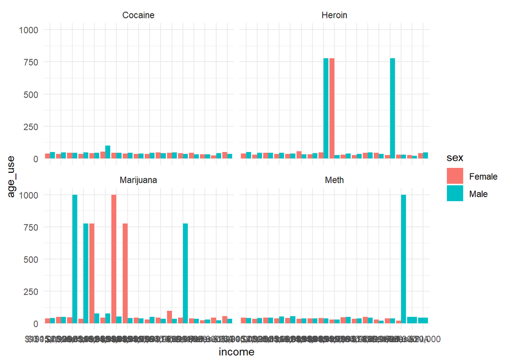

```r
pd <- d %>%
  rename(age_Marijuana = duq210,
         age_Cocaine = duq260,
         age_Heroin = duq300,
         age_Meth = duq340) %>%
  filter(year != 2005) %>%
  select(age_Cocaine, age_Marijuana, age_Heroin, age_Meth, income, sex, ethnicity, sex) %>%
  gather(drug, age_use, age_Cocaine:age_Meth) %>%
  separate(drug, c(NA, "drug"), sep = "_") %>%
  drop_na(age_use)

ggplot(pd, aes(income, age_use)) +
  geom_col(aes(fill = sex), position = "dodge") + #barely any sex differences
  facet_wrap(~ drug)
```

For Revision: * take out sex since there are barely any differences * create one average value to plot instead of distribution * condense income levels * have drug type on x axis and facet by income level (see crimes in denver hw2code) * change colors and theme layout * think of other type of graph (have point estimate with st. error since calculating average) * fct_reorder levels * take out marijana? illicit use * filter out and combine income levels * relevel income levels from lowest to highest * filter out age of use that are coded as missing or denied * calculate mean to plot instead of whatever is plotted above * make error bars for uncertainty * calculate se for mean of age of use

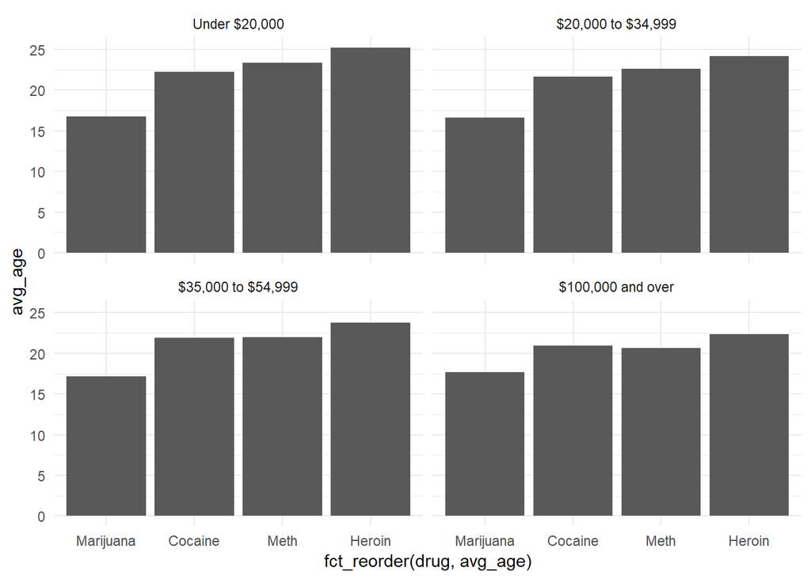

```r
pd1 <- d %>%
  rename(age_Marijuana = duq210,
         age_Cocaine = duq260,
         age_Heroin = duq300,
         age_Meth = duq340) %>%
  filter(year != 2005) %>%
  select(age_Cocaine, age_Marijuana, age_Heroin, age_Meth, income, sex, year, ethnicity, education) %>%
  gather(drug, age_use, age_Cocaine:age_Meth) %>%
  separate(drug, c(NA, "drug"), sep = "_") %>%
  mutate(income = case_when(income == "$0 - $4,999" ~ "Under $20,000", #grouped by 10s instead of 5s
                            income == "$5,000 to $9,999" ~ "Under $20,000",
                            income == "10,000 to $14,999" ~ "Under $20,000",
                            income == "$15,000 to $19,999" ~ "Under $20,000",
                            income == "$20,000 to $24,999" ~ "$20,000 to $34,999",
                            income == "$25,000 to $34,999" ~ "$20,000 to $34,999",
                            income == "$35,000 to $44,999" ~ "$35,000 to $54,999",
                            income == "$45,000 to $54,999" ~ "$35,000 to $54,999",
                            income == "$55,000 to $64,999" ~ "$55,000 to $99,999",
                            income ==  "$65,000 to $74,999" ~ "$55,000 to $99,999",
                            income ==  "$75,000 and Over" ~ "$75,000 and Over",
                            income ==  "Over $20,000" ~ "Over $20,000",
                            income ==  "Under $20,000" ~ "Under $20,000",
                            income ==  "$75,000 to $99,999" ~ "$55,000 to $99,999",
                            income ==  "$100,000 and over" ~ "$100,000 and over",
                            TRUE ~ NA_character_),
         income = factor(income,
                         levels = c("Under $20,000",
                                    "$20,000 to $34,999",
                                    "$35,000 to $54,999",
                                    "55,000 to $99,999",
                                    "$100,000 and over"))) %>%
  naniar::replace_with_na(replace = list(age_use = c(999, 777, 99, 0, 77))) %>%
  drop_na(age_use)

sum_pd1 <- pd1 %>%
  filter(income != "$75,000 and Over" |
         income != "Over $20,000") %>%
  group_by(drug, income) %>%
  summarize(avg_age = mean(age_use),
            n = length(age_use),
            sd = sd(age_use),
            se = sd / sqrt(n))


ggplot(sum_pd1, aes(fct_reorder(drug, avg_age), avg_age)) +
  geom_col() +
  facet_wrap(~ income)
```

```r
#can't really see differences - make jitter with point estimate and se bar
#consider filtering for some years and taking out marijuana again
```

2nd revise:

- plot jittered raw distribution with point and uncertaintly over it
- plot using only 2 years recent data for less overlap/confounds
- add label for average age
- could try stat density

```r
pd1_rev <- pd1 %>%
  mutate(education = factor(education,
                            levels = c("College graduate or above",
                                       "Some college",
                                       "High school graduate/GED",
                                       "No diploma/GED",
                                       TRUE ~ NA_character_)),
         ethnicity_group = case_when(ethnicity == "Hispanic" ~ "Non- White", # combined to be more succinct
                                     ethnicity == "Hispanic" ~ "Non- White",
                                     ethnicity == "White" ~ "White",
                                     ethnicity == "Black" ~ "Non- White",
                                     ethnicity == "Asian" ~ "Non- White",
                                     TRUE ~ NA_character_),
         drug = factor(drug,
                       levels = c("Marijuana",
                                  "Cocaine",
                                  "Meth",
                                  "Heroin"))) %>%
  drop_na(age_use, education)
```

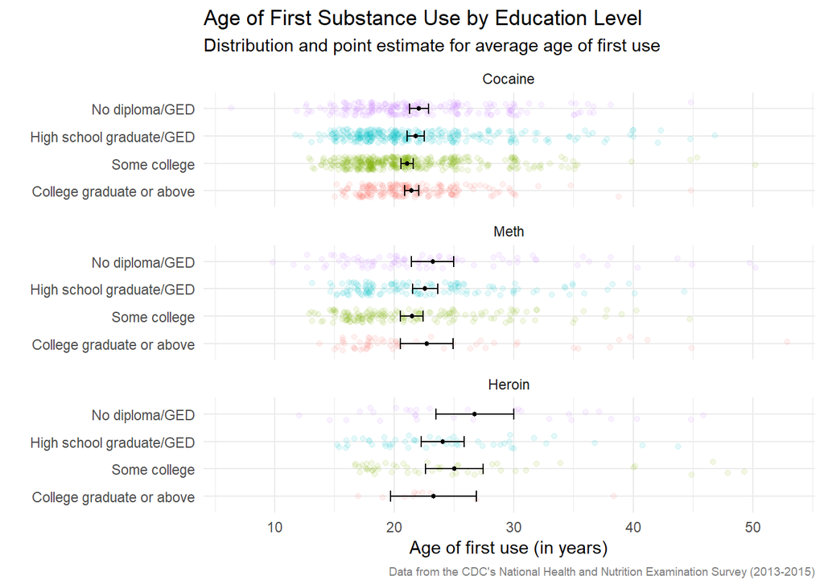

```r
pd1_rev_filter <- pd1_rev %>%
  filter(year == 2015 |
         year == 2013 ) %>%
  filter(drug != "Marijuana")

pd1_rev_sum <- pd1_rev %>%
  filter(year == 2015 |
         year == 2013 ) %>%
  group_by(drug, education) %>%
  summarize(avg_age = mean(age_use),
            n = length(age_use),
            sd = sd(age_use),
            se = sd / sqrt(n)) %>%
  drop_na(education) %>%
  filter(drug != "Marijuana")

p <- ggplot(pd1_rev_sum, aes(education, avg_age)) +
  geom_jitter(aes(x = education, y = age_use, color = education), data = pd1_rev_filter, alpha = .1, width = .25) +
  geom_errorbar(aes(ymin = avg_age + qnorm(.025)*se,
                    ymax = avg_age + qnorm(.975)*se),
                width = .4) +
  geom_point(size = 1) + # add jitter from other dataset (before point)
  facet_wrap(~ drug, ncol = 1) + # added ncol = 1 to see more of variability
  coord_flip() + #coord flip to see labels better and differences in outcome
  theme(legend.position = "none",
        plot.caption = element_text(color = "gray50", size = 7)) +
  labs(y = "Age of first use (in years)",
       x = "",
       title = "Age of First Substance Use by Education Level",
       subtitle = "Distribution and point estimate for average age of first use",
       caption = "Data from the CDC's National Health and Nutrition Examination Survey (2013-2015)")
p
```

- trying out darker theme

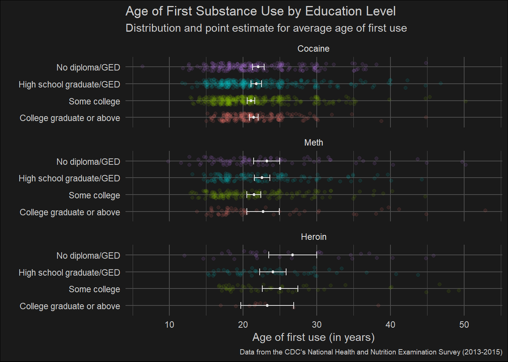

```r
p + theme(plot.background = element_rect(fill = "gray10"),
        axis.text = element_text(colour = "gray80"),
        axis.title = element_text(colour = "gray80"),
        plot.title = element_text(colour = "gray80"),
        plot.subtitle = element_text(colour = "gray80"),
        plot.caption = element_text(colour = "gray80", vjust = 1),
        panel.grid.major = element_line(colour = "gray30"),
        panel.grid.minor = element_line(colour = "gray30"),
        strip.text = element_text(color = "gray90")) +
  geom_errorbar(aes(ymin = avg_age + qnorm(.025)*se,
                    ymax = avg_age + qnorm(.975)*se),
                width = .4,
                color = "gray90") +
  geom_point(size = 1, color = "gray90")
```

- For a general audience

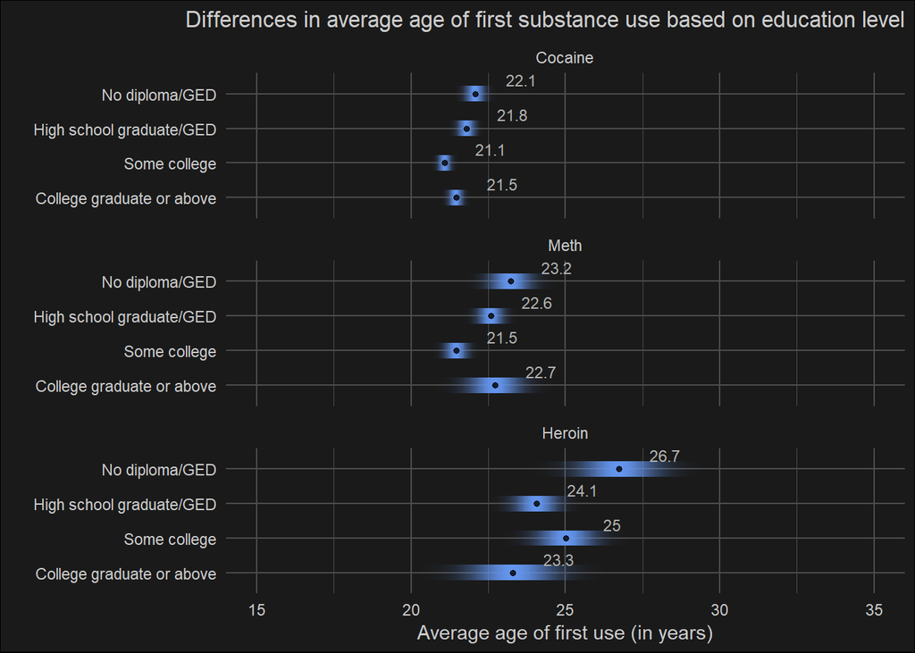

```r
ggplot(pd1_rev_sum, aes(avg_age, education)) +
  stat_confidence_density(aes(moe = se),
                          fill = "cornflowerblue",
                          height = .45) +
  xlim(15, 35) +
  geom_point(alpha = .8, size = 1.25) +
  facet_wrap(~drug, ncol = 1) +
  geom_text(aes(avg_age, education, label = round(avg_age, 1)),
            nudge_x = 1.5,
            nudge_y = .4,
            size = 3,
            color = "gray70") +
  labs(title = "Differences in average age of first substance use based on education level",
       x = "Average age of first use (in years)",
       y = "") +
  theme(plot.background = element_rect(fill = "gray10"),
        axis.text = element_text(colour = "gray80"),
        axis.title = element_text(colour = "gray80"),
        plot.title = element_text(colour = "gray80", hjust = 1, size = 12.5),
        plot.caption = element_text(colour = "gray80", vjust = 1),
        panel.grid.major = element_line(colour = "gray30"),
        panel.grid.minor = element_line(colour = "gray30"),
        strip.text = element_text(color = "gray80"))
```

```r
#limit x axis
# add labels for average age since limiting x axis
#JP - change the color of the average age or to move it over slightly more to the right. I also wonder if changing your x-axis scale to 30 would make this a stronger plot. -JP
```

Suggestions from Peer Review: (1) Your title didn’t print correctly for me (its cut-off on one side or the other, depending on if it was in the console or zoomed in). I changed the hjust to be one and decreased the font to 12.5, and then it worked for me (did this in the code above). (2) I would also think about increased the size of the font within the plot, especially the mean years (or maybe just bolding them?). I felt I was straining my eyes a little to read them.

I really like your use of the dark background and the blue band to display the error bars. I think choosing to turn your error bars into a band as opposed to the lines of error bars over jittered data points displays the patterns of your data clearer, so really good decision!

- exploring ethnicity differences - initial (most likley not using)

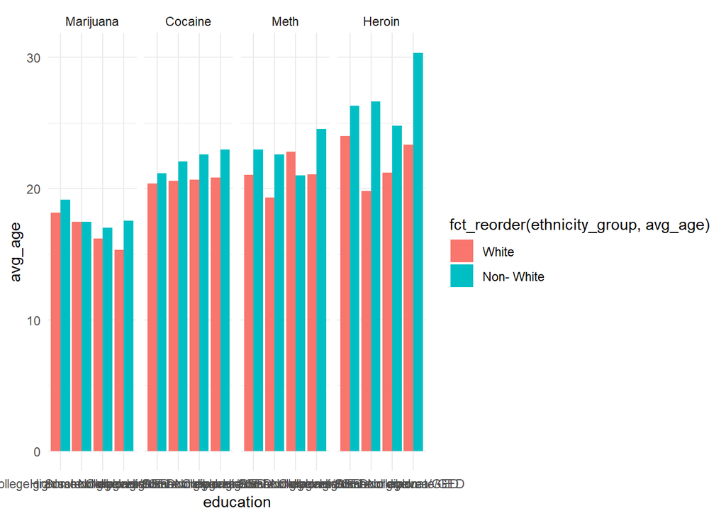

```r
pd_sum_eth <- pd1_rev %>%
  filter(year == 2015) %>%
  group_by(drug, education, ethnicity_group) %>%
  summarize(avg_age = mean(age_use),
            n = length(age_use),
            sd = sd(age_use),
            se = sd / sqrt(n)) %>%
  drop_na(education, ethnicity_group)

ggplot(pd_sum_eth, aes(education, avg_age)) +
  geom_col(aes(fill = fct_reorder(ethnicity_group, avg_age)), position = "dodge") +
  facet_wrap(~ fct_reorder(drug, avg_age), nrow = 1)
```

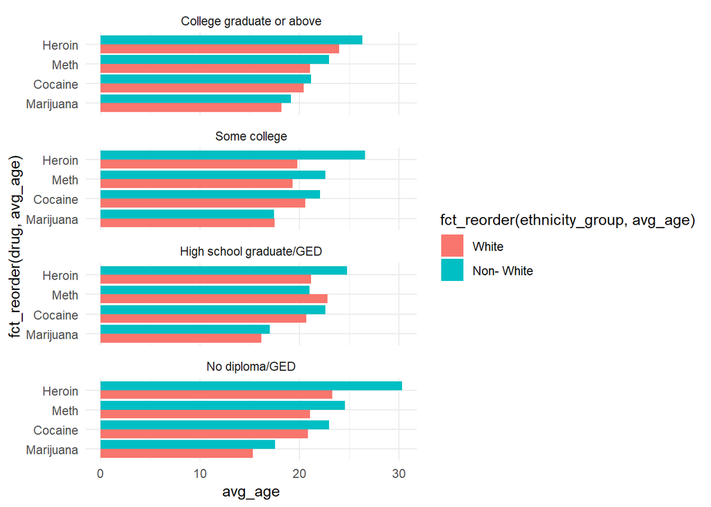

```r
ggplot(pd_sum_eth, aes(fct_reorder(drug, avg_age), avg_age)) +
  geom_col(aes(fill = fct_reorder(ethnicity_group, avg_age)), position = "dodge") +
  facet_wrap(~ education, ncol = 1) +
  coord_flip()
```

Suggestion from Peer Review: (1) I think this is a cool exploration and could be really interesting! I understand this is pretty early on, but I thought that switching the facet to be education and your x-axis (before switching the coords) to be drug type might be easier to read. I changed the above plot in that way. (2) I’d also be interested to see what patterns you find with use as the y-axis as opposed to age, I found myself reading the plot as use instead of age often (so maybe putting that axis under each facet might remove my error).

Either way, a really cool relationship to look at!